# MTH6139 Time Series

Coursework 1

Aimon Haba

March 2024

## 1. Introduction

In this project I will attempt to explore the Johnson & Johnson dataset about the quarterly earnings (dollars) per Johnson & Johnson share in 1960-1980 as well as predict the future quarterly earnings (dollars) per Johnson & Johnson share using time series analysis tools.

### 1.1. Decomposed Time Series

Firstly in this introduction it would be useful to understand the time series of quarterly earnings (dollars) per Johnson & Johnson share in more depth. To get an insight into this time series I will begin by decomposing the time series so we can analyse the trend, seasonality and residual components.

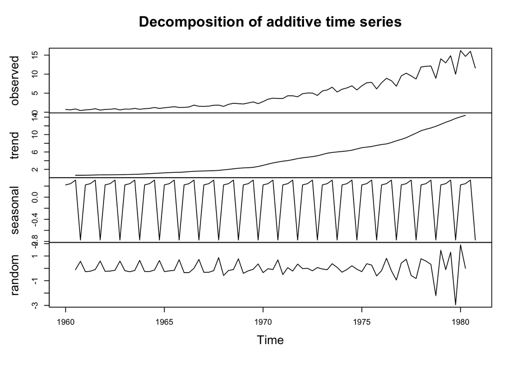

```r
decomposed <- decompose(JohnsonJohnson)
plot(decomposed)
```

Trend component - There is a clear upwards trend, indicating that the quarterly earnings (dollars) per Johnson & Johnson share is increasing over time.

Seasonality component - The seasonality shows patterns that repeat every year (4 quarters). We see that there is clearly low and high points throughout the year that indicates the quarterly earnings (dollars) per Johnson & Johnson share flucuate depending on which quarter of the year we are in.

Random component - Here we can clearly see a case of the random component in the time series increasing (not constant). This is called heteroscedasticity and is bad. A potential solution would be to transform the data using a function to obtain a homoskedastic time series.

## 2. Linear Regression Model

To gain an understanding of the growth of the time series I will begin by running a linear regression model of the data.

```r
JohnsonJohnson_x <- time(JohnsonJohnson)
JohnsonJohnson_y <- JohnsonJohnson
model_linear <- lm(JohnsonJohnson_y~JohnsonJohnson_x)
summary(model_linear)
```

```
##
## Call:
## lm(formula = JohnsonJohnson_y ~ JohnsonJohnson_x)
##
## Residuals:
##     Min      1Q  Median      3Q     Max
## -2.1853 -1.1968 -0.5239  0.8742  5.1229
##
## Coefficients:
##                    Estimate Std. Error t value Pr(>|t|)
## (Intercept)      -1.280e+03  5.926e+01  -21.61   <2e-16 ***
## JohnsonJohnson_x  6.522e-01  3.007e-02   21.69   <2e-16 ***
## ---
## Signif. codes:  0 '***' 0.001 '**' 0.01 '*' 0.05 '.' 0.1 ' ' 1
##
## Residual standard error: 1.671 on 82 degrees of freedom
## Multiple R-squared:  0.8515, Adjusted R-squared:  0.8497
## F-statistic: 470.3 on 1 and 82 DF,  p-value: < 2.2e-16
```

This gives us a basic idea that as time goes on the quarterly earnings per Johnson & Johnson share increases. This indicates that Johnson & Johnson is a steadily growing company.

For further analysis of this model please see the following plots:

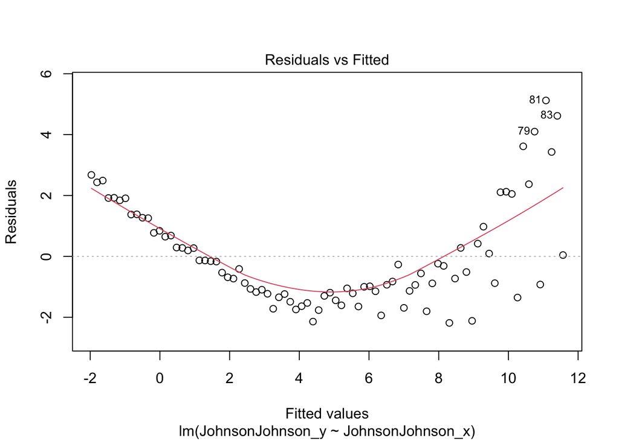

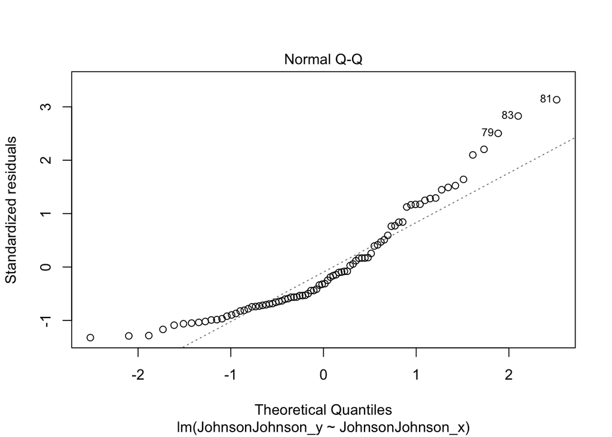

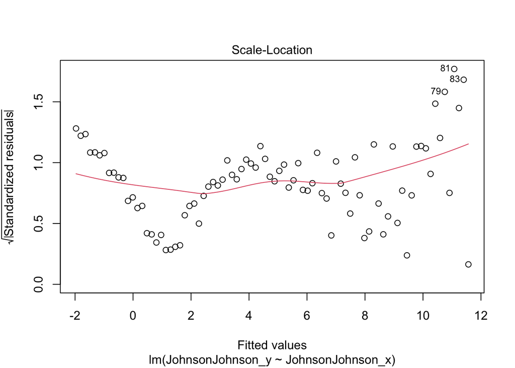

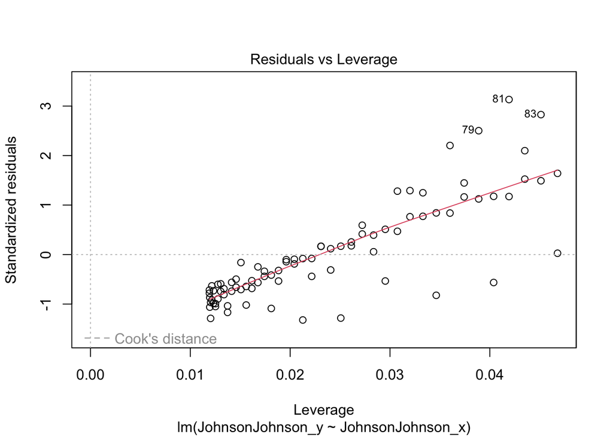

```r
plot(model_linear)
```

These residual plots will allow us to test the assumptions behind the linear regression model.

## 3. Meta Prophet Forecasting Model

Meta Prophet is an extensions of Facebook’s Prophet forecasting system designed for time series forecasting. Relating to this project Meta Prophet is especially useful in financial forecasting as it has the ability to predict future points using our time series JohnsonJohnson.

### 3.1. Meta Prophet Forecasting Model 2 Years Ahead

Now to predict the quarterly earnings (dollars) per Johnson & Johnson share in 1981 and 1982 using the quarterly earnings (dollars) per Johnson & Johnson share data from 1960 - 1980 I will use Meta’s prophet forecasting model.

First we will assign the ds and y to the data frame:

```r
JohnsonJohnson_ds <- zoo::as.yearmon(time(JohnsonJohnson))
JohnsonJohnson_y <- JohnsonJohnson
JohnsonJohnson_df <- data.frame(ds=JohnsonJohnson_ds, y=JohnsonJohnson_y)
```

Now we can create our model:

```r
model_prohet <- prophet::prophet(JohnsonJohnson_df)
```

```
## Disabling weekly seasonality. Run prophet with weekly.seasonality=TRUE to override this.
```

```
## Disabling daily seasonality. Run prophet with daily.seasonality=TRUE to override this.
```

To be able to predict the 1981 and 1982 quarterly earnings (dollars) per Johnson & Johnson share we need to extend the ds set by 2 years (8 quarters):

```r
next_two_years <- prophet::make_future_dataframe(model_prohet, periods = 8, freq = "quarter")
```

Finally we can use our model to predict the quarterly earnings (dollars) per Johnson & Johnson share in 1981 and 1982:

```r
model_prediction <- predict(model_prohet, next_two_years)
```

To visualize our Meta prophet model, let us plot it:

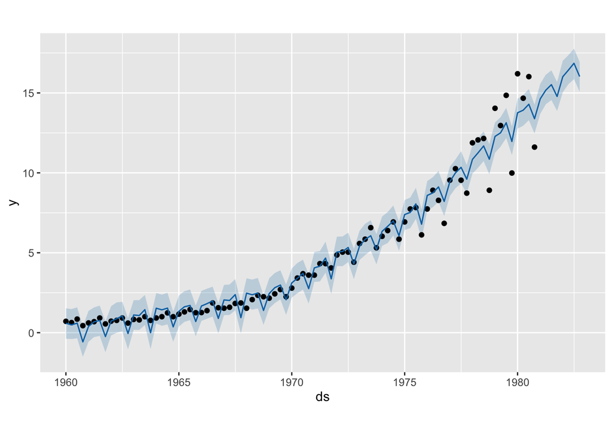

```r
plot(model_prohet, model_prediction)
```

To see the forecast broken down into trend and yearly seasonality please see the plot below:

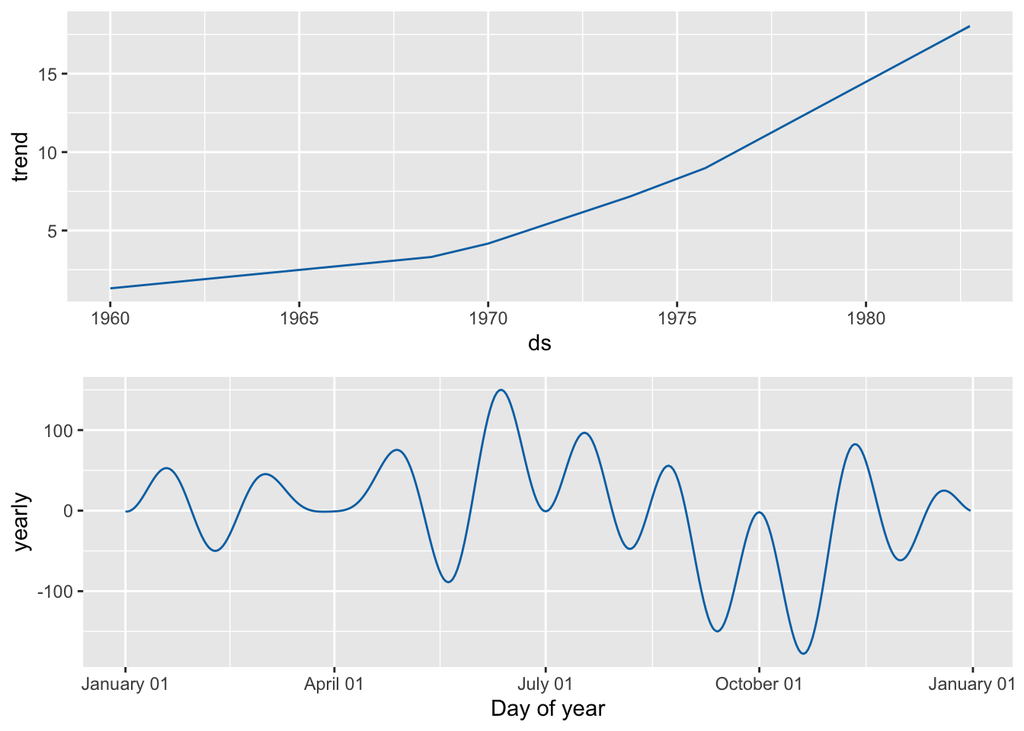

```r
prophet::prophet_plot_components(model_prohet, model_prediction)
```

As we can see the trend is a steady upwards trend. This goes along with the beta_1_hat estimator we saw in our linear regression model earlier. This implies that the quarterly earnings (dollars) per Johnson & Johnson share is increasing over the years.

### 3.2. Meta Prophet Forecasting Model 5 Years Ahead

I will now repeat the steps taking in 3.1. but adapt it so we can forecast the quarterly earnings (dollars) per Johnson & Johnson share in 1981 to 1985 using the quarterly earnings (dollars) per Johnson & Johnson share data from 1960 - 1980.

First we will assign the ds and y to the data frame:

```r
JohnsonJohnson_ds <- zoo::as.yearmon(time(JohnsonJohnson))
JohnsonJohnson_y <- JohnsonJohnson
JohnsonJohnson_df <- data.frame(ds=JohnsonJohnson_ds, y=JohnsonJohnson_y)
```

Now we can create our model:

```r
model_prohet <- prophet::prophet(JohnsonJohnson_df)
```

```
## Disabling weekly seasonality. Run prophet with weekly.seasonality=TRUE to override this.
```

```
## Disabling daily seasonality. Run prophet with daily.seasonality=TRUE to override this.
```

To be able to predict the 1981 to 1985 quarterly earnings (dollars) per Johnson & Johnson share we need to extend the ds set by 5 years (20 quarters):

```r
next_five_years <- prophet::make_future_dataframe(model_prohet, periods = 20, freq = "quarter")
```

Finally we can use our model to predict the quarterly earnings (dollars) per Johnson & Johnson share in 1981 to 1985:

```r
model_prediction <- predict(model_prohet, next_five_years)
```

To visualize our Meta prophet model, let us plot it:

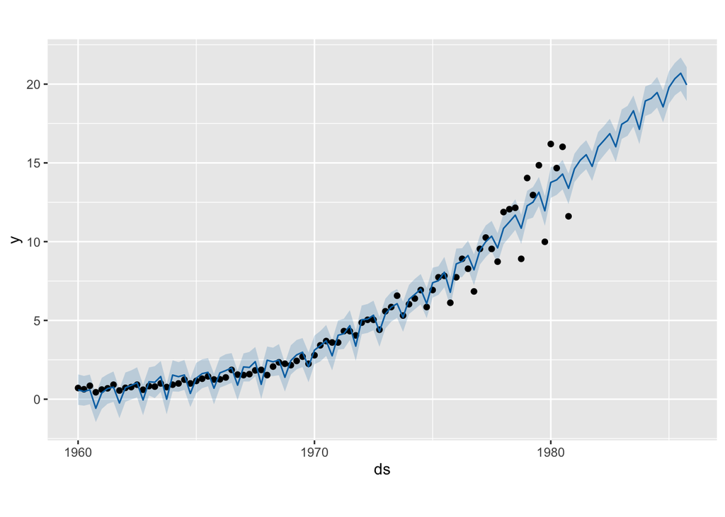

```r
plot(model_prohet, model_prediction)
```

When comparing this to our Meta Prophet Forecasting Model 2 Years Ahead we can see they look fairly similar except the 5 year forecast is longer than the 2 year forecast.

### 3.3. Comparing Meta Prophet Forecast to Today’s reported Earnings per Share

On Yahoo Finance I can see that Johnson & Johnson’s revenue per share is 33.61 in the last 12 months. We can explore our Meta Prophet forecasting to see if our model would predict the same revenue per share using the quarterly earnings (dollars) per Johnson & Johnson share in 1960-1980.

First we will assign the ds and y to the data frame:

```r
JohnsonJohnson_ds <- zoo::as.yearmon(time(JohnsonJohnson))
JohnsonJohnson_y <- JohnsonJohnson
JohnsonJohnson_df <- data.frame(ds=JohnsonJohnson_ds, y=JohnsonJohnson_y)
```

Now we can create our model:

```r
model_prohet <- prophet::prophet(JohnsonJohnson_df)
```

```
## Disabling weekly seasonality. Run prophet with weekly.seasonality=TRUE to override this.
```

```
## Disabling daily seasonality. Run prophet with daily.seasonality=TRUE to override this.
```

To be able to predict today’s quarterly earnings (dollars) per Johnson & Johnson share we need to extend the ds set by 44 years (176 quarters):

```r
today_forecast <- prophet::make_future_dataframe(model_prohet, periods = 176, freq = "quarter")
```

Finally we can use our model to predict the quarterly earnings (dollars) per Johnson & Johnson share today:

```r
model_prediction <- predict(model_prohet, today_forecast)
```

To visualize our Meta prophet model, let us plot it:

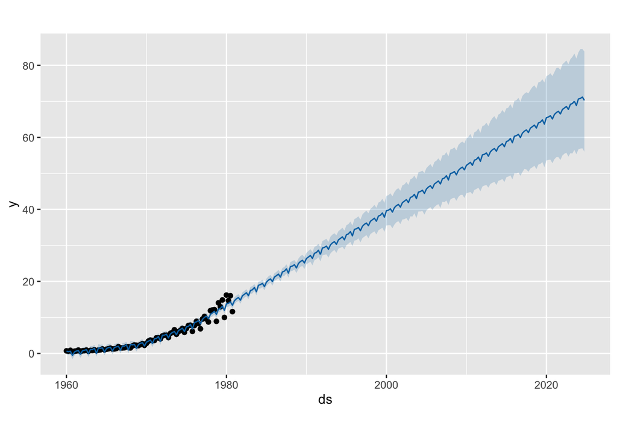

```r
plot(model_prohet, model_prediction)
```

The 2024 forecast for quarterly earnings (dollars) per Johnson & Johnson share are:

```r
tail(model_prediction$yhat, 4)
```

```
## [1] 70.66288 70.82473 71.19647 70.28820
```

In Yahoo finance the Johnson & Johnson’s revenue per share is gathered from reports in the last 12 months so our final value will be the average forecasted quarterly earnings (dollars) per Johnson & Johnson share in 2024 which is :

```r
mean(tail(model_prediction$yhat, 4))
```

```
## [1] 70.74307
```

Our forecasted value of 70.74 is much larger than the actual 33.61 value reported in Yahoo finance. This could be the result of Johnson & Johnson having less growth from 1981-2024 compared to 1960-1980. It is important to note that in this section, we have forecasted for 44 years using only 20 years of past data, so of course the forecast is not going to be very accurate, however it is still fun to see.